# Math 120 Week 3

Ali Miller

11 September, 2020

# Monday Sept 7

## Warm-up example

Suppose we wish to predict cty fuel efficiency based upon engine size (displ). We find the following summary stats:

I.e.: displ is x and cty is y.

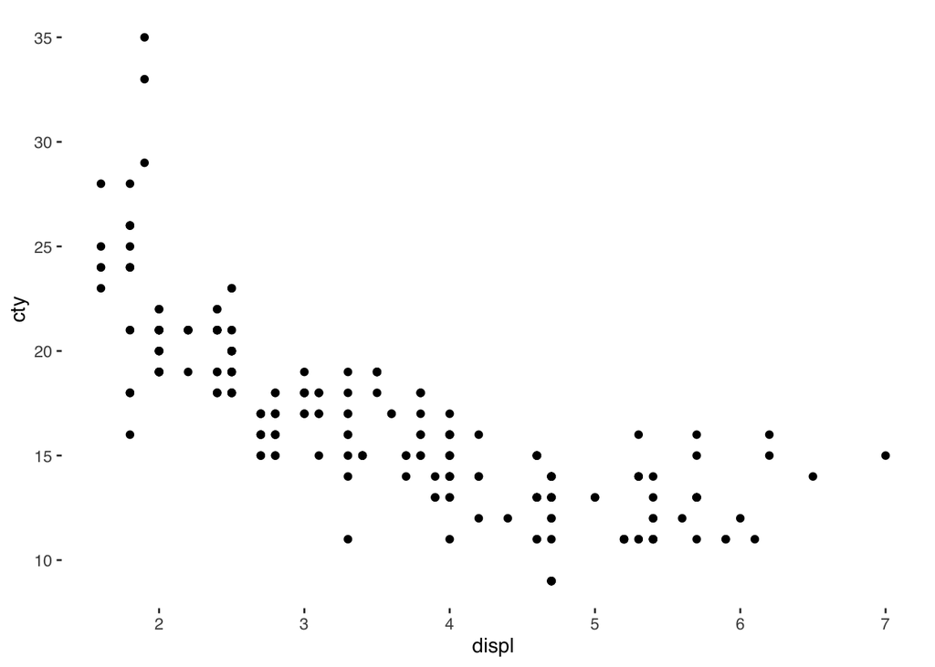

```r
mpg %>% ggplot(aes(displ, cty))+geom_point()
```

Mean displacement: 3.472 L xbar Mean cty mpg: 16.859 mpg ybar Stdev displacement: 1.292 L s_x Stddev cty mpg: 4.256 mpg s_y correlation coeff = -0.799 r

1. Find the equation of the least squres line.

slope = b_1 = r*s_y/s_x = -2.632

Next, intercept:

yint = b_0 = ybar - b_1*xbar 25.997

Thus, the equation:

yhat = 25.997 - 2.632x

2. A new car has an engine size of 2.1 L and city fuel efficiency of 27mpg.

What would our linear model (the least squares line) predict this car’s city mpg? What’s the residual for this measurement?

Prediction: plug in x=2.1

```r
25.997 - 2.632*2.1
```

```
## [1] 20.4698
```

Residual: obs y-value - expected (prediction).

```r
27 - 20.470
```

```
## [1] 6.53
```

Our model under-approximated the cty mpg by 6.53mpg.

## Interpreting slope and intercept

slope = how steep the line is. Specifically: the slope is how much we epect the y-variable to change in response to a 1-unit change in x.

Our slope for predicting mpg based on displ: -2.632. This means that for each additional liter of engine size, we expect the cty fuel effiency to decrease by 2.632L.

yint = y-val when x=0. Here, if the x variable measures 0 units, we predict the y variable to be the y-int.

In our car model, interpret: if a car has an engine size of zero, we expect cty fuel efficienty to be 25.997mpg.

Weird! Car couldn’t have engine size of 0L. In our data, ranged from about 2 to 7. This is **extrapolation**, i.e. making a prediction based on an x value that’s well outside the range of observations. This is bad!

Junk in, junk out! There’s no reason to expect that the pattern continues outside the range of observations.

## Analyzing residuals.

Remember, residuals are errors. So, understanding them is important in understanding how “good” the model.

To see them, we use a visual. **Residual plot**! Its a scatter plot:

x: original x data y: residuals (error)

Example: plot residuals for our mpg model (x=displ, y=cty)

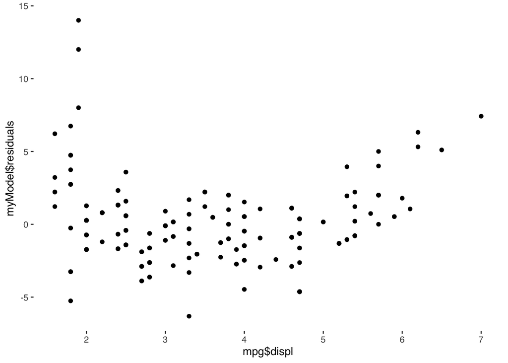

```r
myModel <- lm(mpg$cty~mpg$displ)

qplot(mpg$displ, myModel$residuals)
```